# WeRateDogs Project Analysis Report

##### by Mohanad Salem

After gathering, assessing, and cleaning WeRateDogs Twitter data, I analyzed the dataset to gain insights. The final Twitter archives master dataset contained various features, including tweet text, dog type, image URL, favorite count, retweet count, prediction for the images, and more. Among these features, I focused on retweet count, favorite count, rating, dog type, prediction, and confidence percentage.

Regarding dog breeds, I discovered that Golden Retrievers, Labrador Retrievers, Pembroke, Chihuahua, and Pug were the most commonly predicted breeds in the dataset. However, when it came to breeds with the highest mean retweet and favorite counts, these breeds did not make it to the top 10. Instead, Afghan Hound and Saluki were among the top 5 for both the highest mean retweet and favorite counts.

Interestingly, the breeds with the highest mean dog ratings did not necessarily have high mean retweet and favorite counts, except for the Saluki, which scored high in both categories. Additionally, the Labrador Retriever, which were among the most common breeds, had high average ratings. Concerning dog types, floofers and puppos had higher average ratings compared to doggos and puppers, but this could be due to the fact that the number of dogs classified as floofers and puppos was considerably less than those classified as doggos and puppers.

I created a pie_chart to see the proportions of the predictions in the dataset.

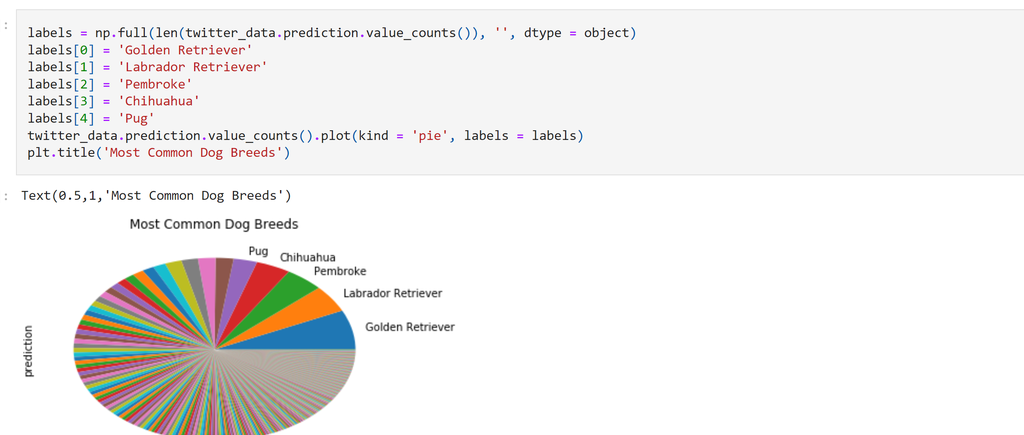

This Pie Chart shows us the most common dog breeds and their sizes in comparison with the rest of the breeds. The 5 breeds combined represent approximately 25% of the total breeds.

I checked the some of the results that we discussed in this project before the wrangling process and the resluts were so different, which is indicating that cleaning the data is mendatory in order to get accurate results.